# Web Scraping Solutions

Curated by Rob Chavez (with code from classmates)

May 17, 2018

# Minihacks

```r
library(dplyr)
library(rvest)
library(ggplot2)
library(stringr)
```

## Minihack 1

Navigate to the nfl page that was used in the first example and pull the big plays count for each game. Once you have all of the data, report the mean and the standard deviation. *If you are feeling ambitious, create a for loop that does this for each week of the season and store each mean and sd in a list.

**This code was commandeered from Cory.**

```r
#Establish the session with the url for the first page
link <- html_session("http://www.nfl.com/scores/2017/REG1")
big_play_cnt <- html_nodes(link, ".big-plays-count") %>%
  html_text() %>%
  as.numeric()

num_weeks <- 17

# creating an empty dataframe to store the weekly data in
big_play_df <- as.data.frame(cbind(team = NA, big_play_cnt = NA, week =  NA)) %>%
  # need this or else you have 1 row of NA's
  na.omit()

#Create a for loop to iterate through each page and to collect the data on each that you need
for (i in 1:num_weeks) {

  #collect all of the team names for each week
  team <- link  %>%
    #identify the css selector that selects all team names
    html_nodes(".team-name") %>%
    #parse the html into a usable form
    html_text()

  #collect all of big play counts
  big_play_cnt <- html_nodes(link, ".big-plays-count") %>%
    html_text() %>%
    as.numeric()


  #Create a dataframe that binds togther the team and the total score for each week
  x <- as.data.frame(cbind(team, big_play_cnt, week = i))
  big_play_df <- rbind(big_play_df, x)
  #specify which page to stop on
  if (i < num_weeks) {
    #follow the link for the next page with the approprite css selector
    link <- link %>%
      follow_link(css = ".active-week+ li .week-item")
  }
}

big_play_df %>%
  mutate(big_play_cnt = as.numeric(big_play_cnt)) %>%
  group_by(week) %>%
  summarize(m_big_plays = mean(big_play_cnt, na.rm = TRUE),
            sd_big_plays = sd(big_play_cnt, na.rm = TRUE))
```

```
## # A tibble: 17 x 3
##    week  m_big_plays sd_big_plays
##    <fct>       <dbl>        <dbl>
##  1 1            5.80         2.71
##  2 2            8.69         5.09
##  3 3            9.62         5.87
##  4 4            5.69         3.96
##  5 5            7.36         5.48
##  6 6            7.57         5.76
##  7 7            7.80         3.66
##  8 8            7.77         5.20
##  9 9            9.00         5.28
## 10 10           8.21         5.93
## 11 11           5.93         6.32
## 12 12           7.69         6.37
## 13 13           8.62         6.42
## 14 14           8.00         6.86
## 15 15           6.25         3.86
## 16 16           6.69         5.04
## 17 17           8.31         5.82
```

## Minihack 2

Go back to the TrustPilot website and look at the reviews. You’ll notice that there is information on each review about the number of reviews the author has posted on the website (Ex: Joey Perry, 4 reviews). Write a function that, for a given webpage, gets the number of reviews each reviewer has made.

If you are having trouble finding the corresponding CSS tag, ask a classmate! Note as well that only pulling the number of other reviews will involve some text manipulation to get rid of irrelevant text.

At the end you should have a function that takes an html object as a parameter and returns a numeric vector of length 20.

**This code was commandeered from Dani. She went a step further and added a column for reviewer in the output.**

```r
# define function
nreviews = function(company){
  # specify web url
  weburl = sprintf('https://www.trustpilot.com/review/www.%s.com', company)

  # pull number of reviews on the first page
  reviews = html_session(weburl) %>%
    html_nodes('.consumer-info__details__review-count') %>%
    html_text() %>%
    str_extract('[0-9]+')

  # pull reviewer names
  reviewer = html_session(weburl) %>%
    html_nodes('.consumer-info__details__name') %>%
    html_text() %>%
    str_squish()

  # return vector with reviewer and number of reviews
  bind_cols(as.data.frame(reviewer), as.data.frame(reviews))
}


# run function on amazon
nreviews('amazon')
```

```
##             reviewer reviews
## 1        Rahul Kumar       3
## 2             John F       2
## 3                jpe       7
## 4            Ignacio       1
## 5      Marta Chamska       2
## 6      Terry Elliott       3
## 7   Tyler O'Sullivan       2
## 8        Lloyd Miles       2
## 9      Jennifer Leen       2
## 10        Cody Moore       6
## 11    Hannah Lanayru       6
## 12             Dylan       3
## 13     Kevin McGuire      10
## 14             Dylan       3
## 15 Tyrone Sandalwood       2
## 16    Betty Hamilton       2
## 17        Henry Webb       2
## 18           Katelyn       2
## 19     Anna Gountras       2
## 20      Proloy Nandy       1
```

```r
# facebook
nreviews('facebook')
```

```
##           reviewer reviews
## 1     John Pierson       1
## 2       Cody Moore       6
## 3   Hannah Lanayru       6
## 4           JOHN S       2
## 5   Jamie kingsten       1
## 6  charmaine Dorma       2
## 7       alex ander       1
## 8         Charli K       2
## 9   aiysha bayoumi       3
## 10    Teng Sin Ong       1
## 11        Easyview       9
## 12    JimmyThunder      20
## 13      Edam Daoud       3
## 14           Janey       4
## 15      Ji Bakkali       6
## 16      Emma Kelly      23
## 17 Binte Johansson       4
## 18   Saurabh Kalra       2
## 19            Matt      17
## 20  James Stretten      17
```

## Minihack 3

The web is a vast ocean of data that is waiting to be scraped. For this hack, be creative. Find a website of your choice and pull some data that you find interesting. Tidy your data and print the head of your dataframe. Perform some simple descriptive statistics and if you’re feeling ambitious create at least one visualization of the trends that you have discovered. There are no limitations to what kind of data you decide to pull (but don’t forget our initial disclaimer!). It can be numbers and it can also be text if you decide that you want to use the skills from the text processing lesson that we covered last week.

If you don’t know where to start, scraping from imdb.com, espn.go.com, news sites, bestplaces.net, is sufficient.

** Here are a couple of example from your classmates that I thought were neat.**

### From Ashley

This code was commandeered from Ashley. She describes it like this:  
*“For Minihack 3 I wanted to compare the success of Marvel and DC movies. I scraped data from IMDb (https://www.imdb.com/list/ls065237713/) to obtain actual ratings for each movie, as well as the gross earnings from each movie. I later plotted these trends across time (i.e., the year each movie aired).”*

```r
#Establish the session with the url for the first page
link2 <- html_session("https://www.imdb.com/list/ls065237713/")

#collect all of the movie titles
movie <- link2  %>%
  html_nodes(".lister-item-header a") %>%
  html_text()

#collect year info and clean
year <- link2  %>%
  html_nodes(".text-muted.unbold") %>%
  html_text()

year <- year[-c(1, 2, 3)] # without fist 3 elements

year[55] <- "(2005)" #gets rid of the random I

year <- as.numeric(str_sub(year[1:69], 2, 5)) #removes parentheses

#collect the ratings for each movie
rating <- link2 %>%
  html_nodes(".ipl-rating-star.small .ipl-rating-star__rating") %>%
  html_text() %>%
  as.numeric()

#collect the gross $ for each movie and clean the data
gross <- link2 %>%
  html_nodes(".text-muted .ghost~ .text-muted+ span") %>%
  html_text()

gross[54] <- "$7.95" #removes the last "M"

gross <- as.numeric(str_sub(gross[1:69], 2, 6)) #removes all $'s and all but one M

#determine whether each movie is associated with Marvel or DC

affiliation <- link2 %>%
  html_nodes(".mode-detail .list-description p") %>%
  html_text()

#create dataframe

data <- as.data.frame(cbind(movie, affiliation, rating, gross, year), stringsAsFactors = FALSE)

#Marvel movie data

Marvel <- filter(data, str_detect(affiliation, "Marvel"))

Marvel$affiliation <- gsub(" -.*","",Marvel[,2])



#DC movie data

DC <- filter(data, str_detect(affiliation, "DC"))

DC$affiliation <- gsub(" -.*","",DC[,2])



#Combined data

Minihack3_data <- rbind(Marvel, DC)

Minihack3_data
```

```
##                                        movie affiliation rating gross year
## 1                     Avengers: Infinity War      Marvel    8.8 558.7 2018
## 2                                      Logan      Marvel    8.1 226.2 2017
## 3                    Guardians of the Galaxy      Marvel    8.1 333.1 2014
## 4                               The Avengers      Marvel    8.1 623.3 2012
## 5                 X-Men: Days of Future Past      Marvel      8 233.9 2014
## 6                                   Deadpool      Marvel      8   363 2016
## 7                 Captain America: Civil War      Marvel    7.8   408 2016
## 8                                   Iron Man      Marvel    7.9 318.4 2008
## 9                             Thor: Ragnarok      Marvel    7.9   315 2017
## 10                             Black Panther      Marvel    7.6 696.6 2018
## 11                            X: First Class      Marvel    7.8 146.4 2011
## 12            Guardians of the Galaxy Vol. 2      Marvel    7.7 389.8 2017
## 13                                Spider-Man      Marvel    7.3 403.7 2002
## 14       Captain America: The Winter Soldier      Marvel    7.8 259.7 2014
```

[output cut: 55 more lines]

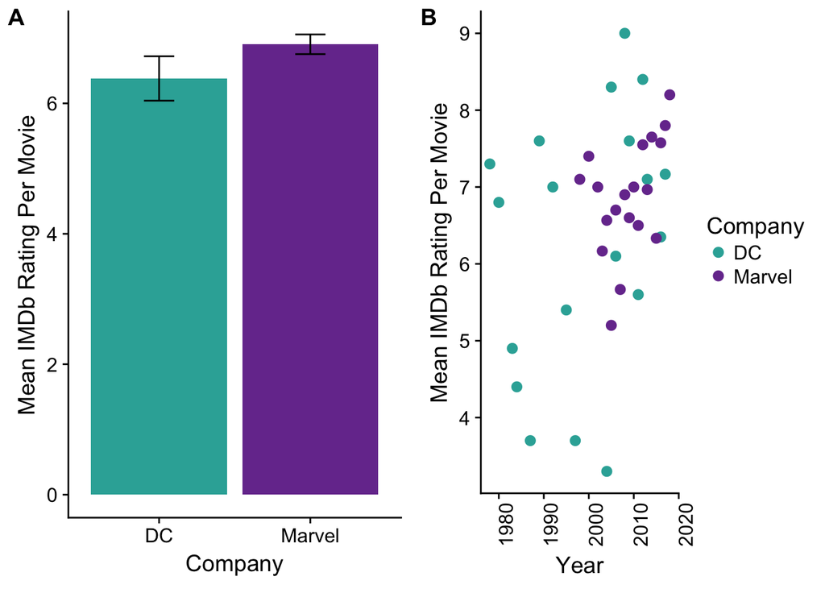

```r
#plots ----------------------------------------------------------------------
 Minihack3_data$affiliation <- as.factor(Minihack3_data$affiliation)
Minihack3_data$rating <- as.numeric(Minihack3_data$rating)
Minihack3_data$gross <- as.numeric(Minihack3_data$gross)
Minihack3_data$year <- as.numeric(Minihack3_data$year)

# data frame for plot A
overall_ratings <-  Minihack3_data %>%
  group_by(affiliation) %>%
  summarise(Mean = mean(rating),
            se = sd(rating)/(sqrt(n())))

overall_gross <-  Minihack3_data %>%
  group_by(affiliation) %>%
  summarise(Mean = mean(gross),
            se = sd(gross)/(sqrt(n())))

# data frame for plot B

rating_time <-  Minihack3_data %>%
  group_by(affiliation, year) %>%
  summarise(Mean = mean(rating),
            se = sd(rating)/(sqrt(n())))

gross_time <-  Minihack3_data %>%
  group_by(affiliation, year) %>%
  summarise(Mean = mean(gross),
            se = sd(gross)/(sqrt(n())))

# plotA saved to plot object
ratings_plotA <- ggplot(overall_ratings, aes(x = affiliation, y = Mean, fill = affiliation)) +
  geom_bar(stat = "identity", position = position_dodge()) +
  scale_fill_manual(values = c("#31AEA6", "#783A9C")) +
  geom_errorbar(aes(ymin = Mean - se, ymax = Mean + se), width = .2, position = position_dodge(.9)) +
  labs(x = 'Company', y = 'Mean IMDb Rating Per Movie') +
  theme(legend.position = "none")

gross_plotA <- ggplot(overall_gross, aes(x = affiliation, y = Mean, fill = affiliation)) +
  geom_bar(stat = "identity", position = position_dodge()) +
  scale_fill_manual(values = c("#A81B56", "#FA7F04")) +
  geom_errorbar(aes(ymin = Mean - se, ymax = Mean + se), width = .2, position = position_dodge(.9)) +
  labs(x = 'Company', y = 'Mean Gross Earnings Per Movie in Millions ($)') +
  theme(legend.position = "none")

# plotB saved to plot object
ratings_plotB <- ggplot(rating_time, aes(x = year, y = Mean, color = affiliation)) +
  geom_point(size = 2.5) +
  scale_color_manual(name = "Company",
                    values = c("#31AEA6", "#783A9C")) +
  labs(x = 'Year', y = 'Mean IMDb Rating Per Movie') +
   theme(axis.text.x = element_text(angle = 90, hjust = 1))

gross_plotB <- ggplot(gross_time, aes(x = year, y = Mean, color = affiliation)) +
  geom_point(size = 2.5) +
  scale_color_manual(name = "Company",
                    values = c("#A81B56", "#FA7F04")) +
  labs(x = 'Year', y = 'Mean Gross Earnings Per Movie in Millions ($)') +
  theme(axis.text.x = element_text(angle = 90, hjust = 1))

# combined plot
library(cowplot)
ratings_combined <- plot_grid(ratings_plotA, ratings_plotB, labels = c("A", "B"))

ratings_combined
```

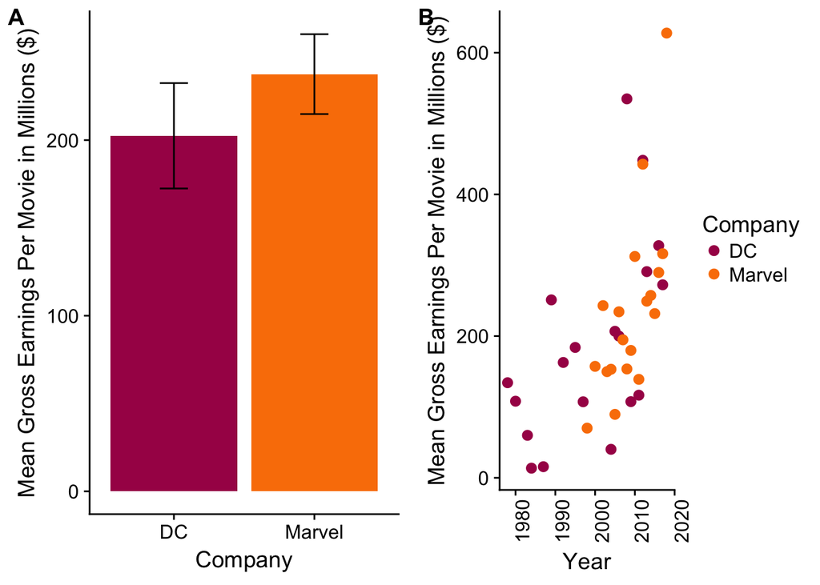

```r
gross_combined <- plot_grid(gross_plotA, gross_plotB, labels = c("A", "B"))

gross_combined
```

### From Bradley

```r
#I created a function to scrape the Wins, ERA, HR, and Year for a given team from 1969 until 2017.
team_stats <- function(team){
  url <- read_html(paste0("https://www.baseball-reference.com/teams/", team, "/pitchteam.shtml#all_yby_team_pitch"))
    nodes <- html_nodes(url, 'table')
    table <- html_table(nodes)
    df <- as.data.frame(table)
    df <- df %>% filter(Year >= 1969, Year < 2018) %>% select(Year, W, ERA, HR)
    df$team <- rep(team, nrow(df))
    return(df)
}

# LMM ---------------------------------------
bal <- team_stats("BAL")
nyy <- team_stats("NYY")
bos <- team_stats("BOS")
tor <- team_stats("TOR")

al_east <- rbind(bal, nyy, bos, tor)
library(lmerTest)

library(lme4)
mod <- lmer(W ~ ERA*HR + (1|team), data = al_east)
summary(mod)
```

```
## Linear mixed model fit by REML t-tests use Satterthwaite approximations
##   to degrees of freedom [lmerMod]
## Formula: W ~ ERA * HR + (1 | team)
##    Data: al_east
##
## REML criterion at convergence: 1397.1
##
## Scaled residuals:
##     Min      1Q  Median      3Q     Max
## -3.3161 -0.6885  0.0802  0.6811  2.0896
##
## Random effects:
##  Groups   Name        Variance Std.Dev.
##  team     (Intercept) 10.66    3.264
##  Residual             94.86    9.740
## Number of obs: 188, groups:  team, 4
##
## Fixed effects:
##              Estimate Std. Error        df t value Pr(>|t|)
## (Intercept)  64.52256   23.06453 182.30000   2.797 0.005704 **
## ERA          -1.84702    5.93459 183.27000  -0.311 0.755980
## HR            0.60603    0.15325 183.81000   3.955 0.000109 ***
## ERA:HR       -0.10284    0.03722 183.30000  -2.763 0.006311 **
## ---
## Signif. codes:  0 '***' 0.001 '**' 0.01 '*' 0.05 '.' 0.1 ' ' 1
##
## Correlation of Fixed Effects:
##        (Intr) ERA    HR
## ERA    -0.978
## HR     -0.943  0.887
## ERA:HR  0.967 -0.950 -0.979
```

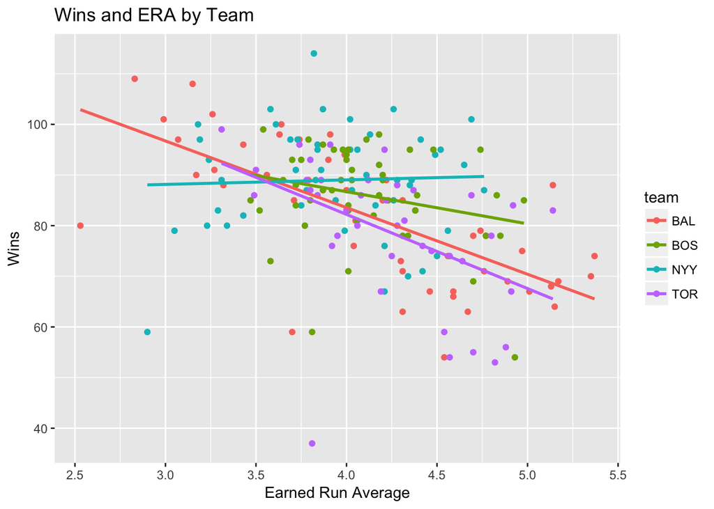

```r
# plots-------------------------------------------------------
ggplot(al_east, aes(y = W, x = ERA, color = team)) +
  geom_point() +
  geom_smooth(method = "lm", se = F)+
  labs(x = "Earned Run Average", y = "Wins", title = "Wins and ERA by Team") + theme_gray()
```

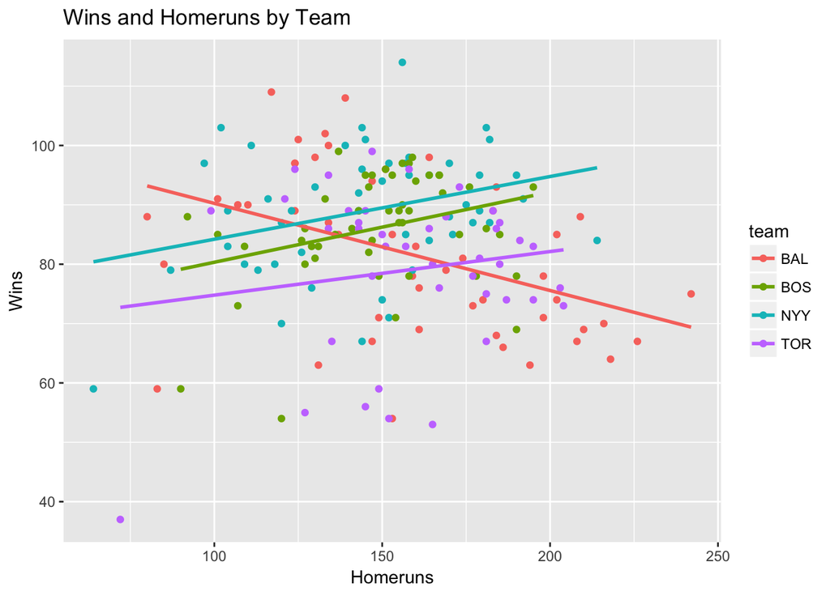

```r
ggplot(al_east, aes(y = W, x = HR, color = team)) +
  geom_point() +
  geom_smooth(method = "lm", se = F) +
  labs(x = "Homeruns", y = "Wins", title = "Wins and Homeruns by Team") + theme_gray()
```